# Who Needs Users? Just Simulate Them!

**Chris Harland :: Data Scientist :: Context Relevant :: @cdubhland**

(work done while at Microsoft)

### Me (Data Scientist):

Not a production programmer...

### Them (Devs):

"Real" programmers

### Problem:

Experimentation platforms need both

I claim unit testing is a place we can all "agree"

# Who needs experimentation?

Well...we do

It is how we (as in humans) establish **causality**

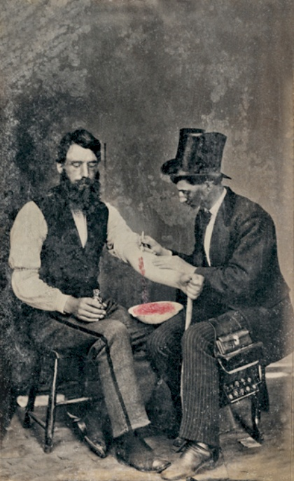

```python
Image(filename='bloodletting.jpg', width = 300)
```

```
 The Burns Archive - Burns Archive via Newsweek, 2.4.2011
```

[figure not shown]

```python
Image(filename='stiff_cover.jpg')
```

Experimentation helps us find the truth in crazy situations

### A/B testing

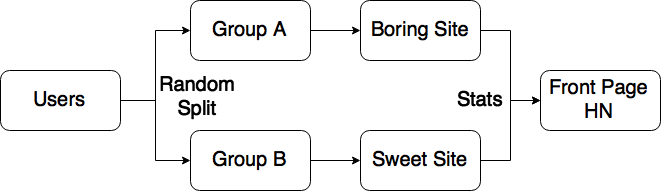

```python
Image(filename='A-B_testing.png')
```

### A/B testing (a bit more complicated than you think...)

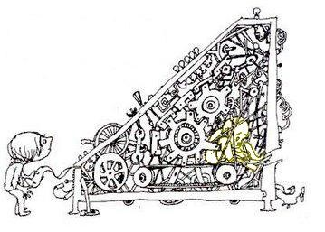

```python
Image(filename='real_testing.jpg')
```

```
Homework Machine - A Light in the Attic - Shell Silverstein
```

### I'm confused...

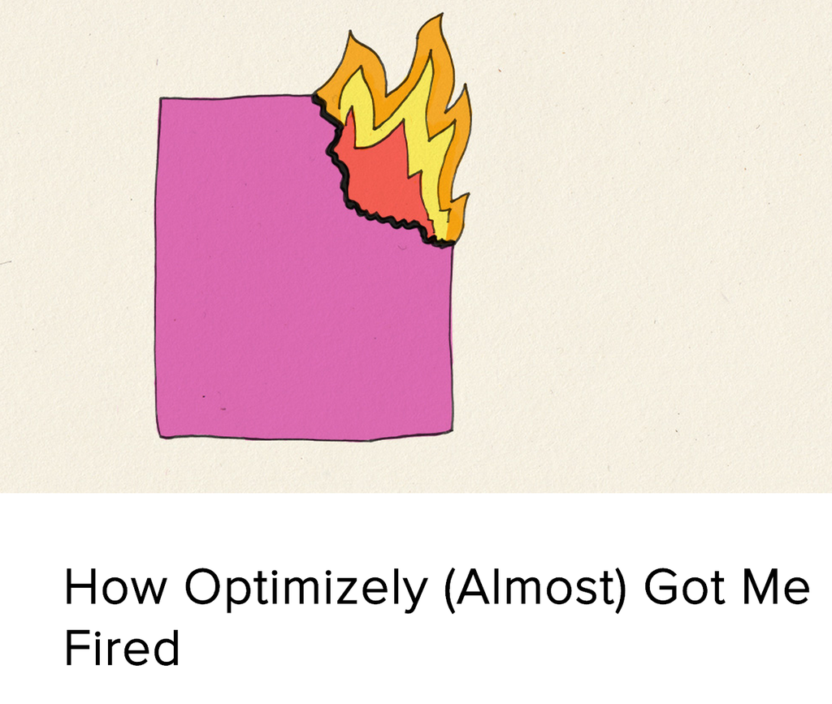

```python
Image(filename='ab_flame_1.png', width = 700)
```

### I'm confused...

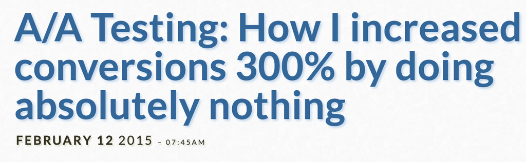

```python
Image(filename='ab_flame_2.png', width = 700)
```

A/B testing simultaneously:

- lifts companies to the pinnacle of optimization
- is a complete waste of time and never works

### A peek into my bias:

Reality : Logs :: Experimental Truth : Scorecard

### So where should we start?

Assume you have a platform (of some kind) and a product (of some kind)

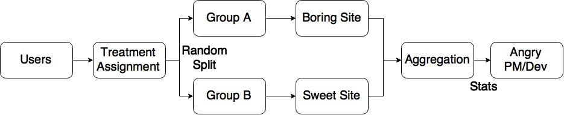

```python
Image(filename='modified_ab_test.png')
```

Common stumbling blocks:

- Bucketing (random numbers are hard)
- Scorecarding (counting, aggregating, and stats)

It's possible to avoid some "pitfalls"

Critical to know your platform works because users are wacky

### What might a unit test look like?

```python
# code mock up
def test_bucket_split(self):
    # Ensure that user bucketing created two equivalent groups
    for metric in self.important_metrics:
        assert abs(self.group_a[metric] - self.group_b[metric]) < self.tolerance
```

But where get these magical groups?

### Make fake humans

### Users are a collection of log lines

Skip the users and just get to the log lines

Anatomy of a log line:

```
1. Human visits
2. Human has choice (often influenced by treatment...you hope)
3. Human makes choice
4. (Optional) Human repeats 2 and 3 additional times
```

Logs are **generated** by a **process**

### Abstract the process

```
1. Present a choice (probability distribution, computer know what these are)
2. Draw from that distribution (nice...a computer can do this)
3. Given the draw, present a second choice (another probability distribution, possibly different)
4. Draw again (hey a computer can do this too)
5. Repeat (oh you bet a computer can do this)
```

Simple process but it captures the essence of the log generation process

The layering of draws and choice of distributions inject flexibility and complexity

### Present a choice and then make it...

```python
# if you like python 2.7 you can high five me @cdubhland
# if you are stunned by my lack of commitment to python 3
# you can send complaints to @joelgrus
from __future__ import division
from scipy import stats
import numpy as np

def get_bernoulli_trial(p, n = 1):
    """ return a bernoulli trial of success or failure with probability p """
    return stats.bernoulli.rvs(p = p, size = n)
```

```python
p = 0.5
n_trials = 10000
print 'Expected p ~ %0.2f and obtained p = %0.2f' % \
(p,np.mean(get_bernoulli_trial(p,n_trials)))
# We expect result to be near p
```

```
Expected p ~ 0.50 and obtained p = 0.50
```

But all decisions aren't this simple =/

### Luckily math can bail us out

```python
# We can make the probability of success a random variable
def get_beta_result(a,b, n = 1):
    """ takes a draw from beta(a,b) used to simulate random rates """
    return stats.beta.rvs(a,b, size = n)

# We can model a collection of user behaviors
def get_expon_result(mu, _lambda, n = 1):
    """ takes a draw from a exponential(mu, lambda) """
    return stats.expon.rvs(mu, _lambda, size = n)

# We can model the collective results of many choices
def get_exp_result(n,p, size = 1):
    """ return the outcome of n bernoulli trials with probability p """
    return stats.binom.rvs(n = n, p = p, size = size)

# Maybe the users visit at different frequencies
def gen_user_visit_freq(n_users = 100, _lambda = 2):
    """ return the total number of visits in a set time delta for the number of given users """
    return stats.poisson.rvs(mu = _lambda, size = n_users)
```

### Simple user click stream log

- Imagine a user comes to your site (this can be a probability)
- User executes a bernoulli trial with probability $p$
  - (where $p$ is the "click through rate")
- If the user had a successful trial call another bernoulli trial with probabiliy $q$
  - where $q$ is the conditional "conversion rate" $P(conv | user, click)$
- Log this as `Timestamp, user_id, impression, click, conversion`
  - `Timestamp` can be draw from distribution of average gap times or assigned sequential

```python
def gen_impression(p_imp = 1.0, p_click = 0.5, p_convert = 0.5):
    """ This function generates an impression, click, conversion based
    on probabilities defined by the input parameters """

    impression = get_bernoulli_trial(p_imp)[0]

    # Note: to speed this up would could draw all trials at once
    # and post process the results to make the outcomes conditional

    if impression == 1:
        did_click = get_bernoulli_trial(p_click)[0]
        # For now we assume only those that click can convert
        if did_click == 1:
            did_convert = get_bernoulli_trial(p_convert)[0]
        else:
            # Optionally this could be a bernoulli with a different p
            # (i.e. the base rate)
            did_convert = 0
        imp_arr = [impression, did_click, did_convert]
        return imp_arr
    else:
        return None
```

```python
[gen_impression() for _ in range(10)]
```

```
[[1, 1, 0],
 [1, 1, 1],
 [1, 0, 0],
 [1, 0, 0],
 [1, 1, 0],
 [1, 1, 0],
 [1, 1, 0],
 [1, 1, 1],
 [1, 0, 0],
 [1, 1, 0]]
```

### Let's get a tiny bit fancy and make this into a real log

```python
import datetime

def gen_log_line(uid, t_current = datetime.datetime.now(), p_imp = 1.0, p_click = 0.5, p_convert = 0.5):
    """ Get a log line for the given user and return with timestamp
    and impression info """

    imp = gen_impression(p_imp, p_click, p_convert)

    if imp is None:
        return None
    else:
        # add a random t_delta
        delta_sec = stats.norm.rvs(loc = 300, scale = 100)
        t_ = t_current + datetime.timedelta(0,delta_sec)
        timestamp = t_.strftime('%Y-%m-%d %I:%M:%S%p')
        log_line = [timestamp, uid] + imp
        return log_line, t_
```

```python
gen_log_line('Trey Causey')[0]
```

```
['2015-07-23 09:55:31PM', 'Trey Causey', 1, 0, 0]
```

### Heck like a really real log

```python
import hashlib
import pandas as pd

def create_hash_id(user, salt):
    """ returns a sha1 hash of user string combined with salt string """
    return hashlib.sha1(salt + '_' + repr(user)).hexdigest()

col_names = ['timestamp','user_id','impression','click','conversion']
user_hash = create_hash_id('Trey Causey', 'Spurs always let you down')
single_log = [gen_log_line(user_hash)[0] for x in range(10)]
pd.DataFrame(single_log, columns = col_names).sort('timestamp') \
.reset_index(drop = True).head()
```

|  | timestamp | user_id | impression | click | conversion |
| --- | --- | --- | --- | --- | --- |
| 0 | 2015-07-23 09:54:01PM | a925ced33b93ee92d0f2f0763169363bf0429ce8 | 1 | 0 | 0 |
| 1 | 2015-07-23 09:54:09PM | a925ced33b93ee92d0f2f0763169363bf0429ce8 | 1 | 1 | 1 |
| 2 | 2015-07-23 09:55:26PM | a925ced33b93ee92d0f2f0763169363bf0429ce8 | 1 | 0 | 0 |
| 3 | 2015-07-23 09:56:32PM | a925ced33b93ee92d0f2f0763169363bf0429ce8 | 1 | 1 | 1 |
| 4 | 2015-07-23 09:57:24PM | a925ced33b93ee92d0f2f0763169363bf0429ce8 | 1 | 0 | 0 |

### But wait...there's more!

In general the formula is:

- Encapsulate a behavior in a probability distribution
  - Poisson for distinct events
  - Exponential for time between those events
  - Binomial for total wins
  - Beta to make random probabilities
  - Normal because it's popular
- Chain those distributions together to form an impression
- Vary the parameters within each chain to generate diversity

The simplicity is deceptive

(this is bayesian stat testing backwards)

### So what's the test?

Find the "unknown" parameters

Simulated logs are noisy instantiations of your supplied parameters

In other words, you put a number into the function and it spit out a ton of hand wavey examples

Your task (well, the dev's task) is to recover that parameter (within reason)

### Revisiting the A/A unit test

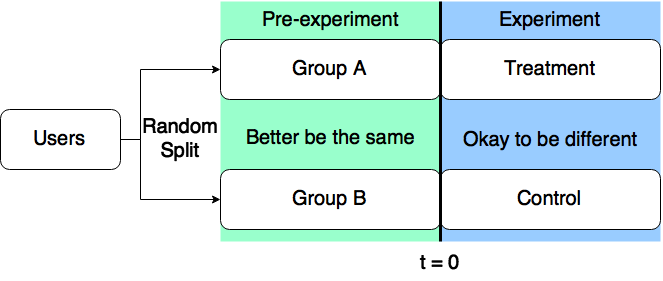

```python
Image(filename='AA.png')
```

### Revisiting the A/A unit test

```python
# code mock up
def test_bucket_split(df_a, df_b, metric):
    # Ensure that user bucketing created two equivalent groups
    assert get_pval(df_a, df_b, metric) > 0.05

## Want to "recover" p > 0.05
```

```python
p_click_control = 0.1
p_convert_control = 0.1
n_users = 1000
n_rows = 10000

# Going to hand wave this function
df_a = simulate_log_vectorized(n_users = n_users,
                               n_rows=n_rows,
                               p_click=p_click_control,
                               p_convert=p_convert_control,
                               strict = False)

df_b = simulate_log_vectorized(n_users = n_users,
                               n_rows=n_rows,
                               p_click=p_click_control,
                               p_convert=p_convert_control,
                               strict = False)
```

```python
df_a.head(3)
```

|  | timestamp | user_id | impression | click | conversion |
| --- | --- | --- | --- | --- | --- |
| 0 | 2015-07-24 20:26:42 | 8638e95cf5c98513fc150c1bd37bb31a78cea297 | 1 | 0 | 0 |
| 1 | 2015-07-24 20:32:38 | a32cd6ce4e51bce288590c28e011ee2d5935cf4a | 1 | 1 | 0 |
| 2 | 2015-07-24 20:39:26 | 06926c24d7d9f98bdb15be4cb487228b4148db23 | 1 | 0 | 0 |

```python
df_b.head(3)
```

|  | timestamp | user_id | impression | click | conversion |
| --- | --- | --- | --- | --- | --- |
| 0 | 2015-07-24 20:24:11 | 2134df724d7821aec520d214eff850c8d972317b | 1 | 0 | 0 |
| 1 | 2015-07-24 20:31:41 | 62a385bc299af570a68429da050c2769f01b4117 | 1 | 0 | 0 |
| 2 | 2015-07-24 20:38:31 | b331f0f87fe7e9f64fd03e659a1b84218cec247f | 1 | 0 | 0 |

### Sweet no `AssertionError`

```python
test_bucket_split(df_a, df_b, 'click')
```

Why am I so wary of random number generators?

[figure not shown]

```python
Image(filename = 'reagan.jpg', width = 500)
```

### But now let's make it "real"

```python
# We often test many metrics
def add_metrics(n_metrics, df_a, df_b):
    for i in range(n_metrics):
        p = np.random.rand()
        # same p for both groups...should be equal
        df_a.loc[:,'metric_%d'%i] = get_bernoulli_trial(p = p, n = len(df_a))
        df_b.loc[:,'metric_%d'%i] = get_bernoulli_trial(p = p, n = len(df_b))
    return df_a, df_b

# We can make a factory of fails
def aa_fail_o_tron(df_a, df_b, n_metrics):
    # add some metrics to the pile
    df_a_mod, df_b_mod = add_metrics(n_metrics, df_a, df_b)

    # Check that all metrics come back not significant
    for i in range(n_metrics):
        test_bucket_split(df_a_mod, df_b_mod, 'metric_%d' % i)
```

```python
aa_fail_o_tron(df_a, df_b, 10) # won't always fail
```

```
---------------------------------------------------------------------------
AssertionError                            Traceback (most recent call last)
<ipython-input-14-285f47eed67d> in <module>()
----> 1 aa_fail_o_tron(df_a, df_b, 10) # won't always fail

<ipython-input-12-2600a27db96f> in aa_fail_o_tron(df_a, df_b, n_metrics)
     15     # Check that all metrics come back not significant
     16     for i in range(n_metrics):
---> 17         test_bucket_split(df_a_mod, df_b_mod, 'metric_%d' % i)

<ipython-input-10-20bf50b24619> in test_bucket_split(df_a, df_b, metric)
      2 def test_bucket_split(df_a, df_b, metric):
      3     # Ensure that user bucketing created two equivalent groups
----> 4     assert get_pval(df_a, df_b, metric) > 0.05
      5
      6 ## Want to "recover" p > 0.05

AssertionError:
```

```python
# But how often does it fail?
def count_dem_fails(df_a, df_b, n_metrics):
    pvals = []
    # add some metrics to the pile
    df_a_mod, df_b_mod = add_metrics(n_metrics, df_a, df_b)

    # Check that all metrics come back not significant
    for i in range(n_metrics):
        pvals.append(get_pval(df_a_mod, df_b_mod, 'metric_%d' % i))

    return sum([pval < 0.05 for pval in pvals])
```

```python
print [count_dem_fails(df_a, df_b, 2) for _ in range(10)]
print [count_dem_fails(df_a, df_b, 5) for _ in range(10)]
print [count_dem_fails(df_a, df_b, 20) for _ in range(10)]
```

```
[0, 0, 0, 0, 0, 0, 0, 0, 0, 1]
[0, 0, 0, 1, 0, 1, 0, 1, 0, 1]
[1, 0, 2, 1, 2, 1, 0, 2, 3, 1]
```

### Be a good coder...pass those tests

```python
def bonferroni_correction(pval, n_metrics):
    # Simply make it harder to fail by lowering pvail
    return pval / n_metrics
```

```python
def test_bucket_split(df_a, df_b, metric, n_metrics = 1):
    # Ensure that user bucketing created two equivalent groups
    assert get_pval(df_a, df_b, metric) > bonferroni_correction(0.05, n_metrics)

def aa_fail_o_tron(df_a, df_b, n_metrics):
    # add some metrics to the pile
    df_a_mod, df_b_mod = add_metrics(n_metrics, df_a, df_b)

    # Check that all metrics come back not significant
    for i in range(n_metrics):
        test_bucket_split(df_a_mod, df_b_mod, 'metric_%d' % i, n_metrics)
```

```python
aa_fail_o_tron(df_a, df_b, 10) # this passes like a lot
```

### But it will still fail (random imbalance)

```python
[aa_fail_o_tron(df_a, df_b, 10) for _ in range(100)]
```

```
---------------------------------------------------------------------------
AssertionError                            Traceback (most recent call last)
<ipython-input-25-9d31d2295423> in <module>()
----> 1 [aa_fail_o_tron(df_a, df_b, 10) for _ in range(100)]

<ipython-input-23-60ba07487cb1> in aa_fail_o_tron(df_a, df_b, n_metrics)
      9     # Check that all metrics come back not significant
     10     for i in range(n_metrics):
---> 11         test_bucket_split(df_a_mod, df_b_mod, 'metric_%d' % i, n_metrics)

<ipython-input-23-60ba07487cb1> in test_bucket_split(df_a, df_b, metric, n_metrics)
      1 def test_bucket_split(df_a, df_b, metric, n_metrics = 1):
      2     # Ensure that user bucketing created two equivalent groups
----> 3     assert get_pval(df_a, df_b, metric) > bonferroni_correction(0.05, n_metrics)
      4
      5 def aa_fail_o_tron(df_a, df_b, n_metrics):

AssertionError:
```

It's okay though...this is expected

### Quickly on aggregation

How should we properly aggregate raw logs before hitting them with stats stick?

#### Example:

How do you calculate the **average page click rate per user**?

I see alot of this:

`df.click.mean()`

Don't do that

### Again...real log stuff looks more like

```python
df_heavy_users = simulate_log_vectorized(n_users = 10,
                                         n_rows= 50000,
                                         p_click=0.8,
                                         p_convert=0.1,
                                         strict=False)

df_light_users = simulate_log_vectorized(n_users = 1000,
                                         n_rows= 10000,
                                         p_click=0.1,
                                         p_convert=0.1,
                                         strict=False)

df_users = pd.concat([df_heavy_users, df_light_users])
```

```python
print 'Impression level click average: %0.3f' % df_users.click.mean()
print 'User level click average: %0.3f' % df_users.groupby('user_id').click.mean().mean()
```

```
Impression level click average: 0.684
User level click average: 0.108
```

#### Oh but it gets important

Let's say your awesome experiment lifts heavy users CTR ~10%

```python
df_heavy_users_moved = simulate_log_vectorized(n_users = 10,
                                         n_rows= 50000,
                                         p_click=0.88,
                                         p_convert=0.1,
                                         strict=False)

df_users_moved = pd.concat([df_heavy_users_moved, df_light_users])
```

```python
print 'Impression level click average: %0.3f' % df_users_moved.click.mean()
print 'User level click average: %0.3f' % df_users_moved.groupby('user_id').click.mean().mean()
```

```
Impression level click average: 0.752
User level click average: 0.109
```

```python
click_report(df_users, df_users_moved)
```

```
Impression level control average: 0.684
Impression level treatment average: 0.752
Lift: 0.10

User level control click average: 0.108
User level treatment click average: 0.109
Lift: 0.01
```

### Works the other way too

Let's say 10% of your light users exhibited a 10% lift

```python
df_heavy_users = simulate_log_vectorized(n_users = 10,
                                         n_rows= 50000,
                                         p_click=0.8,
                                         p_convert=0.1,
                                         strict=False)

df_stubborn_light_users = simulate_log_vectorized(n_users = 900,
                                                  n_rows= 9000,
                                                  p_click=0.1,
                                                  p_convert=0.1,
                                                  strict=False)

df_cooperative_light_users = simulate_log_vectorized(n_users = 100,
                                                     n_rows= 1000,
                                                     p_click=0.11,
                                                     p_convert=0.1,
                                                     strict=False)


df_users_le_sigh = pd.concat([df_heavy_users,
                              df_stubborn_light_users,
                              df_cooperative_light_users])
```

```python
click_report(df_users, df_users_le_sigh)
```

```
Impression level control average: 0.684
Impression level treatment average: 0.684
Lift: 0.00

User level control click average: 0.108
User level treatment click average: 0.110
Lift: 0.02
```

Impression level rollups aren't sensitive enough =/

Unit test for sensitivity (too much or too little)

Avoid making ship mistakes

```python
def correct_rollup(df, injected_lift, ratio):
    # ratio - fraction of users effected by injected_lift

    # calculate the user level lift
    user_lift = user_level_lift(df)
    impression_level_lift = impression_level_lift(df)

    # Example case: ratio < 1.0 and injected_lift >= 0.10
    assert user_lift < impression_level_lift
```

### Some stuff to think about

- Unit testing is common ground
- Log simulation is surprisingly accurate and useful
- A/B testing pitfalls lurk in every part of your stack (fear monger)
- Users are wacky...prepare yourself for them

# Who Needs Users? Just Simulate Them!

**Chris Harland :: Data Scientist :: Context Relevant :: @cdubhland**